# Risk Factor Analysis

## Outcome Variable

**Outcome Variable:** ever_stunted

## Predictor Variables

**Intervention Variable:** feducyrs

**Adjustment Set:**

- arm
- W_mage
- meducyrs
- W_mhtcm
- W_gagebrth
- W_birthwt
- W_birthlen
- single
- delta_W_mage
- delta_meducyrs
- delta_W_mhtcm
- delta_W_gagebrth
- delta_W_birthwt
- delta_W_birthlen
- delta_single

## Stratifying Variables

The analysis was stratified on these variable(s):

- agecat
- studyid
- country

## Data Summary

| agecat | studyid | country | feducyrs | ever_stunted | n_cell | n |
| --- | --- | --- | --- | --- | --- | --- |
| 0-24 months | ki0047075b-MAL-ED | BANGLADESH | High | 0 | 31 | 149 |
| 0-24 months | ki0047075b-MAL-ED | BANGLADESH | High | 1 | 23 | 149 |
| 0-24 months | ki0047075b-MAL-ED | BANGLADESH | Low | 0 | 15 | 149 |
| 0-24 months | ki0047075b-MAL-ED | BANGLADESH | Low | 1 | 25 | 149 |
| 0-24 months | ki0047075b-MAL-ED | BANGLADESH | Medium | 0 | 20 | 149 |
| 0-24 months | ki0047075b-MAL-ED | BANGLADESH | Medium | 1 | 35 | 149 |
| 0-24 months | ki0047075b-MAL-ED | INDIA | High | 0 | 18 | 147 |
| 0-24 months | ki0047075b-MAL-ED | INDIA | High | 1 | 26 | 147 |
| 0-24 months | ki0047075b-MAL-ED | INDIA | Low | 0 | 28 | 147 |
| 0-24 months | ki0047075b-MAL-ED | INDIA | Low | 1 | 31 | 147 |
| 0-24 months | ki0047075b-MAL-ED | INDIA | Medium | 0 | 18 | 147 |
| 0-24 months | ki0047075b-MAL-ED | INDIA | Medium | 1 | 26 | 147 |
| 0-24 months | ki0047075b-MAL-ED | NEPAL | High | 0 | 32 | 98 |
| 0-24 months | ki0047075b-MAL-ED | NEPAL | High | 1 | 10 | 98 |
| 0-24 months | ki0047075b-MAL-ED | NEPAL | Low | 0 | 16 | 98 |
| 0-24 months | ki0047075b-MAL-ED | NEPAL | Low | 1 | 12 | 98 |
| 0-24 months | ki0047075b-MAL-ED | NEPAL | Medium | 0 | 15 | 98 |
| 0-24 months | ki0047075b-MAL-ED | NEPAL | Medium | 1 | 13 | 98 |
| 0-24 months | ki0047075b-MAL-ED | PERU | High | 0 | 45 | 250 |
| 0-24 months | ki0047075b-MAL-ED | PERU | High | 1 | 75 | 250 |
| 0-24 months | ki0047075b-MAL-ED | PERU | Low | 0 | 28 | 250 |
| 0-24 months | ki0047075b-MAL-ED | PERU | Low | 1 | 41 | 250 |
| 0-24 months | ki0047075b-MAL-ED | PERU | Medium | 0 | 20 | 250 |
| 0-24 months | ki0047075b-MAL-ED | PERU | Medium | 1 | 41 | 250 |
| 0-24 months | ki0047075b-MAL-ED | SOUTH AFRICA | High | 0 | 15 | 110 |
| 0-24 months | ki0047075b-MAL-ED | SOUTH AFRICA | High | 1 | 28 | 110 |
| 0-24 months | ki0047075b-MAL-ED | SOUTH AFRICA | Low | 0 | 18 | 110 |
| 0-24 months | ki0047075b-MAL-ED | SOUTH AFRICA | Low | 1 | 19 | 110 |
| 0-24 months | ki0047075b-MAL-ED | SOUTH AFRICA | Medium | 0 | 11 | 110 |
| 0-24 months | ki0047075b-MAL-ED | SOUTH AFRICA | Medium | 1 | 19 | 110 |

[output cut: 330 more lines]

The following strata were considered:

- agecat: 0-24 months, studyid: ki0047075b-MAL-ED, country: BANGLADESH
- agecat: 0-24 months, studyid: ki0047075b-MAL-ED, country: INDIA
- agecat: 0-24 months, studyid: ki0047075b-MAL-ED, country: NEPAL
- agecat: 0-24 months, studyid: ki0047075b-MAL-ED, country: PERU
- agecat: 0-24 months, studyid: ki0047075b-MAL-ED, country: SOUTH AFRICA
- agecat: 0-24 months, studyid: ki0047075b-MAL-ED, country: TANZANIA, UNITED REPUBLIC OF
- agecat: 0-24 months, studyid: ki1000304b-SAS-CompFeed, country: INDIA
- agecat: 0-24 months, studyid: ki1000304b-SAS-FoodSuppl, country: INDIA
- agecat: 0-24 months, studyid: ki1017093b-PROVIDE, country: BANGLADESH
- agecat: 0-24 months, studyid: ki1017093c-NIH-Crypto, country: BANGLADESH
- agecat: 0-24 months, studyid: ki1066203-TanzaniaChild2, country: TANZANIA, UNITED REPUBLIC OF
- agecat: 0-24 months, studyid: ki1113344-GMS-Nepal, country: NEPAL
- agecat: 0-24 months, studyid: ki1119695-PROBIT, country: BELARUS
- agecat: 0-24 months, studyid: ki1126311-ZVITAMBO, country: ZIMBABWE
- agecat: 0-24 months, studyid: ki1135781-COHORTS, country: GUATEMALA
- agecat: 0-24 months, studyid: ki1135781-COHORTS, country: INDIA
- agecat: 0-24 months, studyid: ki1135781-COHORTS, country: PHILIPPINES
- agecat: 0-24 months, studyid: ki1148112-LCNI-5, country: MALAWI
- agecat: 0-24 months, studyid: kiGH5241-JiVitA-3, country: BANGLADESH
- agecat: 0-24 months, studyid: kiGH5241-JiVitA-4, country: BANGLADESH
- agecat: 0-6 months, studyid: ki0047075b-MAL-ED, country: BANGLADESH
- agecat: 0-6 months, studyid: ki0047075b-MAL-ED, country: INDIA
- agecat: 0-6 months, studyid: ki0047075b-MAL-ED, country: NEPAL
- agecat: 0-6 months, studyid: ki0047075b-MAL-ED, country: PERU
- agecat: 0-6 months, studyid: ki0047075b-MAL-ED, country: SOUTH AFRICA
- agecat: 0-6 months, studyid: ki0047075b-MAL-ED, country: TANZANIA, UNITED REPUBLIC OF
- agecat: 0-6 months, studyid: ki1000304b-SAS-CompFeed, country: INDIA
- agecat: 0-6 months, studyid: ki1000304b-SAS-FoodSuppl, country: INDIA
- agecat: 0-6 months, studyid: ki1017093b-PROVIDE, country: BANGLADESH
- agecat: 0-6 months, studyid: ki1017093c-NIH-Crypto, country: BANGLADESH
- agecat: 0-6 months, studyid: ki1066203-TanzaniaChild2, country: TANZANIA, UNITED REPUBLIC OF
- agecat: 0-6 months, studyid: ki1113344-GMS-Nepal, country: NEPAL
- agecat: 0-6 months, studyid: ki1119695-PROBIT, country: BELARUS
- agecat: 0-6 months, studyid: ki1126311-ZVITAMBO, country: ZIMBABWE
- agecat: 0-6 months, studyid: ki1135781-COHORTS, country: GUATEMALA
- agecat: 0-6 months, studyid: ki1135781-COHORTS, country: INDIA
- agecat: 0-6 months, studyid: ki1135781-COHORTS, country: PHILIPPINES
- agecat: 0-6 months, studyid: ki1148112-LCNI-5, country: MALAWI
- agecat: 0-6 months, studyid: kiGH5241-JiVitA-3, country: BANGLADESH
- agecat: 0-6 months, studyid: kiGH5241-JiVitA-4, country: BANGLADESH
- agecat: 6-24 months, studyid: ki0047075b-MAL-ED, country: BANGLADESH
- agecat: 6-24 months, studyid: ki0047075b-MAL-ED, country: INDIA
- agecat: 6-24 months, studyid: ki0047075b-MAL-ED, country: NEPAL
- agecat: 6-24 months, studyid: ki0047075b-MAL-ED, country: PERU
- agecat: 6-24 months, studyid: ki0047075b-MAL-ED, country: SOUTH AFRICA
- agecat: 6-24 months, studyid: ki0047075b-MAL-ED, country: TANZANIA, UNITED REPUBLIC OF
- agecat: 6-24 months, studyid: ki1000304b-SAS-CompFeed, country: INDIA
- agecat: 6-24 months, studyid: ki1000304b-SAS-FoodSuppl, country: INDIA
- agecat: 6-24 months, studyid: ki1017093b-PROVIDE, country: BANGLADESH
- agecat: 6-24 months, studyid: ki1017093c-NIH-Crypto, country: BANGLADESH
- agecat: 6-24 months, studyid: ki1066203-TanzaniaChild2, country: TANZANIA, UNITED REPUBLIC OF
- agecat: 6-24 months, studyid: ki1113344-GMS-Nepal, country: NEPAL
- agecat: 6-24 months, studyid: ki1119695-PROBIT, country: BELARUS
- agecat: 6-24 months, studyid: ki1126311-ZVITAMBO, country: ZIMBABWE
- agecat: 6-24 months, studyid: ki1135781-COHORTS, country: GUATEMALA
- agecat: 6-24 months, studyid: ki1135781-COHORTS, country: INDIA
- agecat: 6-24 months, studyid: ki1135781-COHORTS, country: PHILIPPINES
- agecat: 6-24 months, studyid: ki1148112-LCNI-5, country: MALAWI
- agecat: 6-24 months, studyid: kiGH5241-JiVitA-3, country: BANGLADESH
- agecat: 6-24 months, studyid: kiGH5241-JiVitA-4, country: BANGLADESH

### Dropped Strata

Some strata were dropped due to rare outcomes:

- agecat: 0-24 months, studyid: ki0047075b-MAL-ED, country: TANZANIA, UNITED REPUBLIC OF
- agecat: 0-6 months, studyid: ki0047075b-MAL-ED, country: NEPAL
- agecat: 6-24 months, studyid: ki0047075b-MAL-ED, country: NEPAL
- agecat: 6-24 months, studyid: ki0047075b-MAL-ED, country: TANZANIA, UNITED REPUBLIC OF

## Methods Detail

We’re interested in the causal parameters $E[Y_a]$ for all values of $a \in \mathcal{A}$. These parameters represent the mean outcome if, possibly contrary to fact, we intervened to set all units to have $A=a$. Under the randomization and positivity assumptions, these are identified by the statistical parameters $\psi_a=E_W[E_{Y|A,W}(Y|A=a,W)]$. In addition, we’re interested in the mean of $Y$, $E[Y]$ under no intervention (the observed mean). We will estimate these parameters by using SuperLearner to fit the relevant likelihood factors – $E_{Y|A,W}(Y|A=a,W)$ and $p(A=a|W)$, and then updating our likelihood fit using a joint TMLE.

For unadjusted analyses ($W=\{\}$), initial likelihoods were estimated using Lrnr_glm to estimate the simple $E(Y|A)$ and Lrnr_mean to estimate $p(A)$. For adjusted analyses, a small library containing Lrnr_glmnet, Lrnr_xgboost, and Lrnr_mean was used.

Having estimated these parameters, we will then use the delta method to estimate relative risks and attributable risks relative to a prespecified baseline level of $A$.

# Results Detail

## Results Plots

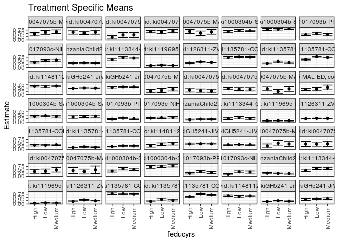

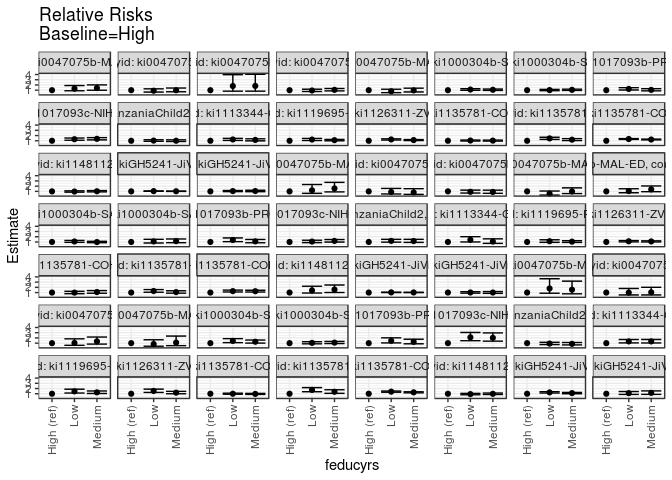

[figure not shown]

[figure not shown]

## Results Table

### Parameter: TSM

| agecat | studyid | country | intervention_level | baseline_level | estimate | ci_lower | ci_upper |
| --- | --- | --- | --- | --- | --- | --- | --- |
| 0-24 months | ki0047075b-MAL-ED | BANGLADESH | High | NA | 0.4438314 | 0.3149484 | 0.5727144 |
| 0-24 months | ki0047075b-MAL-ED | BANGLADESH | Low | NA | 0.5753495 | 0.4297861 | 0.7209129 |
| 0-24 months | ki0047075b-MAL-ED | BANGLADESH | Medium | NA | 0.6270766 | 0.4962063 | 0.7579469 |
| 0-24 months | ki0047075b-MAL-ED | INDIA | High | NA | 0.5918905 | 0.4437186 | 0.7400623 |
| 0-24 months | ki0047075b-MAL-ED | INDIA | Low | NA | 0.5312418 | 0.4064189 | 0.6560647 |
| 0-24 months | ki0047075b-MAL-ED | INDIA | Medium | NA | 0.5854690 | 0.4371583 | 0.7337796 |
| 0-24 months | ki0047075b-MAL-ED | NEPAL | High | NA | 0.2135412 | 0.0798687 | 0.3472138 |
| 0-24 months | ki0047075b-MAL-ED | NEPAL | Low | NA | 0.3831309 | 0.1924786 | 0.5737832 |
| 0-24 months | ki0047075b-MAL-ED | NEPAL | Medium | NA | 0.3875440 | 0.1980382 | 0.5770499 |
| 0-24 months | ki0047075b-MAL-ED | PERU | High | NA | 0.6302550 | 0.5476732 | 0.7128369 |
| 0-24 months | ki0047075b-MAL-ED | PERU | Low | NA | 0.5947885 | 0.4784317 | 0.7111453 |
| 0-24 months | ki0047075b-MAL-ED | PERU | Medium | NA | 0.6713637 | 0.5522999 | 0.7904275 |
| 0-24 months | ki0047075b-MAL-ED | SOUTH AFRICA | High | NA | 0.6449991 | 0.4986529 | 0.7913453 |
| 0-24 months | ki0047075b-MAL-ED | SOUTH AFRICA | Low | NA | 0.5112558 | 0.3457651 | 0.6767466 |
| 0-24 months | ki0047075b-MAL-ED | SOUTH AFRICA | Medium | NA | 0.6194756 | 0.4393654 | 0.7995858 |
| 0-24 months | ki1000304b-SAS-CompFeed | INDIA | High | NA | 0.6448668 | 0.5812922 | 0.7084413 |
| 0-24 months | ki1000304b-SAS-CompFeed | INDIA | Low | NA | 0.7223371 | 0.6546675 | 0.7900066 |
| 0-24 months | ki1000304b-SAS-CompFeed | INDIA | Medium | NA | 0.6944671 | 0.6521512 | 0.7367831 |
| 0-24 months | ki1000304b-SAS-FoodSuppl | INDIA | High | NA | 0.7981505 | 0.7242706 | 0.8720303 |
| 0-24 months | ki1000304b-SAS-FoodSuppl | INDIA | Low | NA | 0.8139050 | 0.7512412 | 0.8765688 |
| 0-24 months | ki1000304b-SAS-FoodSuppl | INDIA | Medium | NA | 0.8534256 | 0.7981794 | 0.9086717 |
| 0-24 months | ki1017093b-PROVIDE | BANGLADESH | High | NA | 0.3969888 | 0.3402853 | 0.4536924 |
| 0-24 months | ki1017093b-PROVIDE | BANGLADESH | Low | NA | 0.4909278 | 0.4317957 | 0.5500600 |
| 0-24 months | ki1017093b-PROVIDE | BANGLADESH | Medium | NA | 0.4206520 | 0.3594557 | 0.4818483 |
| 0-24 months | ki1017093c-NIH-Crypto | BANGLADESH | High | NA | 0.3944222 | 0.3444863 | 0.4443580 |
| 0-24 months | ki1017093c-NIH-Crypto | BANGLADESH | Low | NA | 0.5131397 | 0.4538092 | 0.5724702 |
| 0-24 months | ki1017093c-NIH-Crypto | BANGLADESH | Medium | NA | 0.5411591 | 0.4821823 | 0.6001359 |
| 0-24 months | ki1066203-TanzaniaChild2 | TANZANIA, UNITED REPUBLIC OF | High | NA | 0.3394258 | 0.2973214 | 0.3815301 |
| 0-24 months | ki1066203-TanzaniaChild2 | TANZANIA, UNITED REPUBLIC OF | Low | NA | 0.3515939 | 0.3257750 | 0.3774128 |
| 0-24 months | ki1066203-TanzaniaChild2 | TANZANIA, UNITED REPUBLIC OF | Medium | NA | 0.3416014 | 0.3061939 | 0.3770089 |

[output cut: 138 more lines]

### Parameter: E(Y)

| agecat | studyid | country | intervention_level | baseline_level | estimate | ci_lower | ci_upper |
| --- | --- | --- | --- | --- | --- | --- | --- |
| 0-24 months | ki0047075b-MAL-ED | BANGLADESH | NA | NA | 0.5570470 | 0.4770190 | 0.6370750 |
| 0-24 months | ki0047075b-MAL-ED | INDIA | NA | NA | 0.5646258 | 0.4842023 | 0.6450494 |
| 0-24 months | ki0047075b-MAL-ED | NEPAL | NA | NA | 0.3571429 | 0.2617885 | 0.4524972 |
| 0-24 months | ki0047075b-MAL-ED | PERU | NA | NA | 0.6280000 | 0.5679657 | 0.6880343 |
| 0-24 months | ki0047075b-MAL-ED | SOUTH AFRICA | NA | NA | 0.6000000 | 0.5080312 | 0.6919688 |
| 0-24 months | ki1000304b-SAS-CompFeed | INDIA | NA | NA | 0.6908497 | 0.6505448 | 0.7311545 |
| 0-24 months | ki1000304b-SAS-FoodSuppl | INDIA | NA | NA | 0.8277512 | 0.7915095 | 0.8639929 |
| 0-24 months | ki1017093b-PROVIDE | BANGLADESH | NA | NA | 0.4342857 | 0.3975409 | 0.4710305 |
| 0-24 months | ki1017093c-NIH-Crypto | BANGLADESH | NA | NA | 0.4775726 | 0.4419904 | 0.5131548 |
| 0-24 months | ki1066203-TanzaniaChild2 | TANZANIA, UNITED REPUBLIC OF | NA | NA | 0.3466219 | 0.3275107 | 0.3657331 |
| 0-24 months | ki1113344-GMS-Nepal | NEPAL | NA | NA | 0.6755408 | 0.6380799 | 0.7130017 |
| 0-24 months | ki1119695-PROBIT | BELARUS | NA | NA | 0.1652568 | 0.1463320 | 0.1841817 |
| 0-24 months | ki1126311-ZVITAMBO | ZIMBABWE | NA | NA | 0.3929015 | 0.3847209 | 0.4010821 |
| 0-24 months | ki1135781-COHORTS | GUATEMALA | NA | NA | 0.7672000 | 0.7437624 | 0.7906376 |
| 0-24 months | ki1135781-COHORTS | INDIA | NA | NA | 0.3780235 | 0.3530310 | 0.4030160 |
| 0-24 months | ki1135781-COHORTS | PHILIPPINES | NA | NA | 0.6899306 | 0.6730355 | 0.7068256 |
| 0-24 months | ki1148112-LCNI-5 | MALAWI | NA | NA | 0.6371464 | 0.6040748 | 0.6702180 |
| 0-24 months | kiGH5241-JiVitA-3 | BANGLADESH | NA | NA | 0.4915971 | 0.4836947 | 0.4994995 |
| 0-24 months | kiGH5241-JiVitA-4 | BANGLADESH | NA | NA | 0.5795971 | 0.5574204 | 0.6017738 |
| 0-6 months | ki0047075b-MAL-ED | BANGLADESH | NA | NA | 0.3422819 | 0.2658404 | 0.4187234 |
| 0-6 months | ki0047075b-MAL-ED | INDIA | NA | NA | 0.3061224 | 0.2313639 | 0.3808810 |
| 0-6 months | ki0047075b-MAL-ED | PERU | NA | NA | 0.4280000 | 0.3665434 | 0.4894566 |
| 0-6 months | ki0047075b-MAL-ED | SOUTH AFRICA | NA | NA | 0.3727273 | 0.2819539 | 0.4635007 |
| 0-6 months | ki0047075b-MAL-ED | TANZANIA, UNITED REPUBLIC OF | NA | NA | 0.4009434 | 0.3348159 | 0.4670709 |
| 0-6 months | ki1000304b-SAS-CompFeed | INDIA | NA | NA | 0.4250164 | 0.3969651 | 0.4530677 |
| 0-6 months | ki1000304b-SAS-FoodSuppl | INDIA | NA | NA | 0.3894231 | 0.3425088 | 0.4363374 |
| 0-6 months | ki1017093b-PROVIDE | BANGLADESH | NA | NA | 0.2385714 | 0.2069753 | 0.2701675 |
| 0-6 months | ki1017093c-NIH-Crypto | BANGLADESH | NA | NA | 0.3021108 | 0.2694011 | 0.3348205 |
| 0-6 months | ki1066203-TanzaniaChild2 | TANZANIA, UNITED REPUBLIC OF | NA | NA | 0.1951322 | 0.1792173 | 0.2110471 |
| 0-6 months | ki1113344-GMS-Nepal | NEPAL | NA | NA | 0.2778702 | 0.2420275 | 0.3137129 |
| 0-6 months | ki1119695-PROBIT | BELARUS | NA | NA | 0.0977315 | 0.0847284 | 0.1107345 |
| 0-6 months | ki1126311-ZVITAMBO | ZIMBABWE | NA | NA | 0.2559789 | 0.2486637 | 0.2632941 |
| 0-6 months | ki1135781-COHORTS | GUATEMALA | NA | NA | 0.3196078 | 0.2909760 | 0.3482397 |
| 0-6 months | ki1135781-COHORTS | INDIA | NA | NA | 0.1639690 | 0.1447117 | 0.1832264 |
| 0-6 months | ki1135781-COHORTS | PHILIPPINES | NA | NA | 0.2381944 | 0.2226342 | 0.2537546 |
| 0-6 months | ki1148112-LCNI-5 | MALAWI | NA | NA | 0.3558052 | 0.2982716 | 0.4133389 |
| 0-6 months | kiGH5241-JiVitA-3 | BANGLADESH | NA | NA | 0.4088773 | 0.4013389 | 0.4164158 |
| 0-6 months | kiGH5241-JiVitA-4 | BANGLADESH | NA | NA | 0.3464052 | 0.3252865 | 0.3675239 |
| 6-24 months | ki0047075b-MAL-ED | BANGLADESH | NA | NA | 0.3595506 | 0.2592902 | 0.4598109 |
| 6-24 months | ki0047075b-MAL-ED | INDIA | NA | NA | 0.4042553 | 0.3045164 | 0.5039942 |
| 6-24 months | ki0047075b-MAL-ED | PERU | NA | NA | 0.4132231 | 0.3251210 | 0.5013252 |
| 6-24 months | ki0047075b-MAL-ED | SOUTH AFRICA | NA | NA | 0.4237288 | 0.2965568 | 0.5509008 |
| 6-24 months | ki1000304b-SAS-CompFeed | INDIA | NA | NA | 0.5024631 | 0.4586872 | 0.5462389 |
| 6-24 months | ki1000304b-SAS-FoodSuppl | INDIA | NA | NA | 0.7572016 | 0.7031798 | 0.8112234 |
| 6-24 months | ki1017093b-PROVIDE | BANGLADESH | NA | NA | 0.2997812 | 0.2577294 | 0.3418330 |
| 6-24 months | ki1017093c-NIH-Crypto | BANGLADESH | NA | NA | 0.2628458 | 0.2244546 | 0.3012371 |
| 6-24 months | ki1066203-TanzaniaChild2 | TANZANIA, UNITED REPUBLIC OF | NA | NA | 0.2263323 | 0.2057897 | 0.2468748 |
| 6-24 months | ki1113344-GMS-Nepal | NEPAL | NA | NA | 0.5623529 | 0.5151323 | 0.6095736 |
| 6-24 months | ki1119695-PROBIT | BELARUS | NA | NA | 0.0761786 | 0.0621943 | 0.0901630 |
| 6-24 months | ki1126311-ZVITAMBO | ZIMBABWE | NA | NA | 0.2426433 | 0.2330974 | 0.2521891 |
| 6-24 months | ki1135781-COHORTS | GUATEMALA | NA | NA | 0.7617329 | 0.7327499 | 0.7907158 |
| 6-24 months | ki1135781-COHORTS | INDIA | NA | NA | 0.2663274 | 0.2410848 | 0.2915700 |
| 6-24 months | ki1135781-COHORTS | PHILIPPINES | NA | NA | 0.6482312 | 0.6273346 | 0.6691278 |
| 6-24 months | ki1148112-LCNI-5 | MALAWI | NA | NA | 0.5983027 | 0.5621404 | 0.6344650 |
| 6-24 months | kiGH5241-JiVitA-3 | BANGLADESH | NA | NA | 0.2163973 | 0.2069603 | 0.2258344 |
| 6-24 months | kiGH5241-JiVitA-4 | BANGLADESH | NA | NA | 0.3764535 | 0.3511984 | 0.4017086 |

### Parameter: RR

| agecat | studyid | country | intervention_level | baseline_level | estimate | ci_lower | ci_upper |
| --- | --- | --- | --- | --- | --- | --- | --- |
| 0-24 months | ki0047075b-MAL-ED | BANGLADESH | High | High | 1.0000000 | 1.0000000 | 1.000000 |
| 0-24 months | ki0047075b-MAL-ED | BANGLADESH | Low | High | 1.2963245 | 0.8887666 | 1.890775 |
| 0-24 months | ki0047075b-MAL-ED | BANGLADESH | Medium | High | 1.4128711 | 0.9912717 | 2.013782 |
| 0-24 months | ki0047075b-MAL-ED | INDIA | High | High | 1.0000000 | 1.0000000 | 1.000000 |
| 0-24 months | ki0047075b-MAL-ED | INDIA | Low | High | 0.8975340 | 0.6405300 | 1.257657 |
| 0-24 months | ki0047075b-MAL-ED | INDIA | Medium | High | 0.9891509 | 0.6947578 | 1.408289 |
| 0-24 months | ki0047075b-MAL-ED | NEPAL | High | High | 1.0000000 | 1.0000000 | 1.000000 |
| 0-24 months | ki0047075b-MAL-ED | NEPAL | Low | High | 1.7941776 | 0.8104697 | 3.971862 |
| 0-24 months | ki0047075b-MAL-ED | NEPAL | Medium | High | 1.8148439 | 0.8144629 | 4.043964 |
| 0-24 months | ki0047075b-MAL-ED | PERU | High | High | 1.0000000 | 1.0000000 | 1.000000 |
| 0-24 months | ki0047075b-MAL-ED | PERU | Low | High | 0.9437267 | 0.7486173 | 1.189687 |
| 0-24 months | ki0047075b-MAL-ED | PERU | Medium | High | 1.0652254 | 0.8594925 | 1.320204 |
| 0-24 months | ki0047075b-MAL-ED | SOUTH AFRICA | High | High | 1.0000000 | 1.0000000 | 1.000000 |
| 0-24 months | ki0047075b-MAL-ED | SOUTH AFRICA | Low | High | 0.7926458 | 0.5329531 | 1.178879 |
| 0-24 months | ki0047075b-MAL-ED | SOUTH AFRICA | Medium | High | 0.9604286 | 0.6635086 | 1.390220 |
| 0-24 months | ki1000304b-SAS-CompFeed | INDIA | High | High | 1.0000000 | 1.0000000 | 1.000000 |
| 0-24 months | ki1000304b-SAS-CompFeed | INDIA | Low | High | 1.1201338 | 0.9807775 | 1.279291 |
| 0-24 months | ki1000304b-SAS-CompFeed | INDIA | Medium | High | 1.0769157 | 0.9560919 | 1.213008 |
| 0-24 months | ki1000304b-SAS-FoodSuppl | INDIA | High | High | 1.0000000 | 1.0000000 | 1.000000 |
| 0-24 months | ki1000304b-SAS-FoodSuppl | INDIA | Low | High | 1.0197388 | 0.9046930 | 1.149414 |
| 0-24 months | ki1000304b-SAS-FoodSuppl | INDIA | Medium | High | 1.0692540 | 0.9555238 | 1.196521 |
| 0-24 months | ki1017093b-PROVIDE | BANGLADESH | High | High | 1.0000000 | 1.0000000 | 1.000000 |
| 0-24 months | ki1017093b-PROVIDE | BANGLADESH | Low | High | 1.2366288 | 1.0345261 | 1.478214 |
| 0-24 months | ki1017093b-PROVIDE | BANGLADESH | Medium | High | 1.0596066 | 0.8717975 | 1.287875 |
| 0-24 months | ki1017093c-NIH-Crypto | BANGLADESH | High | High | 1.0000000 | 1.0000000 | 1.000000 |
| 0-24 months | ki1017093c-NIH-Crypto | BANGLADESH | Low | High | 1.3009909 | 1.1067692 | 1.529296 |
| 0-24 months | ki1017093c-NIH-Crypto | BANGLADESH | Medium | High | 1.3720302 | 1.1743896 | 1.602932 |
| 0-24 months | ki1066203-TanzaniaChild2 | TANZANIA, UNITED REPUBLIC OF | High | High | 1.0000000 | 1.0000000 | 1.000000 |
| 0-24 months | ki1066203-TanzaniaChild2 | TANZANIA, UNITED REPUBLIC OF | Low | High | 1.0358492 | 0.8985371 | 1.194145 |
| 0-24 months | ki1066203-TanzaniaChild2 | TANZANIA, UNITED REPUBLIC OF | Medium | High | 1.0064098 | 0.8576166 | 1.181018 |

[output cut: 138 more lines]

### Parameter: PAR

| agecat | studyid | country | intervention_level | baseline_level | estimate | ci_lower | ci_upper |
| --- | --- | --- | --- | --- | --- | --- | --- |
| 0-24 months | ki0047075b-MAL-ED | BANGLADESH | High | NA | 0.1132156 | 0.0098952 | 0.2165359 |
| 0-24 months | ki0047075b-MAL-ED | INDIA | High | NA | -0.0272646 | -0.1498889 | 0.0953597 |
| 0-24 months | ki0047075b-MAL-ED | NEPAL | High | NA | 0.1436016 | 0.0314390 | 0.2557642 |
| 0-24 months | ki0047075b-MAL-ED | PERU | High | NA | -0.0022550 | -0.0608849 | 0.0563748 |
| 0-24 months | ki0047075b-MAL-ED | SOUTH AFRICA | High | NA | -0.0449991 | -0.1616775 | 0.0716793 |
| 0-24 months | ki1000304b-SAS-CompFeed | INDIA | High | NA | 0.0459829 | -0.0123810 | 0.1043468 |
| 0-24 months | ki1000304b-SAS-FoodSuppl | INDIA | High | NA | 0.0296007 | -0.0323559 | 0.0915574 |
| 0-24 months | ki1017093b-PROVIDE | BANGLADESH | High | NA | 0.0372969 | -0.0082193 | 0.0828131 |
| 0-24 months | ki1017093c-NIH-Crypto | BANGLADESH | High | NA | 0.0831504 | 0.0454402 | 0.1208606 |
| 0-24 months | ki1066203-TanzaniaChild2 | TANZANIA, UNITED REPUBLIC OF | High | NA | 0.0071962 | -0.0306258 | 0.0450181 |
| 0-24 months | ki1113344-GMS-Nepal | NEPAL | High | NA | 0.0879098 | 0.0190964 | 0.1567233 |
| 0-24 months | ki1119695-PROBIT | BELARUS | High | NA | 0.0206449 | 0.0043255 | 0.0369643 |
| 0-24 months | ki1126311-ZVITAMBO | ZIMBABWE | High | NA | 0.0481295 | 0.0214780 | 0.0747810 |
| 0-24 months | ki1135781-COHORTS | GUATEMALA | High | NA | 0.0325350 | -0.0186433 | 0.0837132 |
| 0-24 months | ki1135781-COHORTS | INDIA | High | NA | 0.0687927 | 0.0419174 | 0.0956680 |
| 0-24 months | ki1135781-COHORTS | PHILIPPINES | High | NA | 0.1015691 | 0.0797617 | 0.1233764 |
| 0-24 months | ki1148112-LCNI-5 | MALAWI | High | NA | -0.0029987 | -0.0507940 | 0.0447966 |
| 0-24 months | kiGH5241-JiVitA-3 | BANGLADESH | High | NA | 0.0114059 | 0.0023734 | 0.0204385 |
| 0-24 months | kiGH5241-JiVitA-4 | BANGLADESH | High | NA | 0.0277178 | -0.0216228 | 0.0770584 |
| 0-6 months | ki0047075b-MAL-ED | BANGLADESH | High | NA | 0.0812179 | -0.0181309 | 0.1805668 |
| 0-6 months | ki0047075b-MAL-ED | INDIA | High | NA | -0.0381675 | -0.1570405 | 0.0807054 |
| 0-6 months | ki0047075b-MAL-ED | PERU | High | NA | -0.0249968 | -0.0804686 | 0.0304750 |
| 0-6 months | ki0047075b-MAL-ED | SOUTH AFRICA | High | NA | -0.0691332 | -0.1835487 | 0.0452823 |
| 0-6 months | ki0047075b-MAL-ED | TANZANIA, UNITED REPUBLIC OF | High | NA | 0.0072525 | -0.0426790 | 0.0571839 |
| 0-6 months | ki1000304b-SAS-CompFeed | INDIA | High | NA | 0.0142351 | -0.0263883 | 0.0548585 |
| 0-6 months | ki1000304b-SAS-FoodSuppl | INDIA | High | NA | 0.0305959 | -0.0457292 | 0.1069210 |
| 0-6 months | ki1017093b-PROVIDE | BANGLADESH | High | NA | 0.0350666 | 0.0001902 | 0.0699430 |
| 0-6 months | ki1017093c-NIH-Crypto | BANGLADESH | High | NA | 0.0240384 | -0.0074687 | 0.0555456 |
| 0-6 months | ki1066203-TanzaniaChild2 | TANZANIA, UNITED REPUBLIC OF | High | NA | 0.0266137 | -0.0041600 | 0.0573874 |
| 0-6 months | ki1113344-GMS-Nepal | NEPAL | High | NA | 0.0448428 | -0.0178026 | 0.1074882 |
| 0-6 months | ki1119695-PROBIT | BELARUS | High | NA | 0.0074807 | -0.0060378 | 0.0209992 |
| 0-6 months | ki1126311-ZVITAMBO | ZIMBABWE | High | NA | 0.0232477 | 0.0025487 | 0.0439467 |
| 0-6 months | ki1135781-COHORTS | GUATEMALA | High | NA | 0.0069558 | -0.0480777 | 0.0619893 |
| 0-6 months | ki1135781-COHORTS | INDIA | High | NA | 0.0194200 | 0.0030070 | 0.0358330 |
| 0-6 months | ki1135781-COHORTS | PHILIPPINES | High | NA | 0.0360427 | 0.0189627 | 0.0531226 |
| 0-6 months | ki1148112-LCNI-5 | MALAWI | High | NA | 0.0843214 | -0.0051498 | 0.1737925 |
| 0-6 months | kiGH5241-JiVitA-3 | BANGLADESH | High | NA | 0.0074278 | -0.0005407 | 0.0153963 |
| 0-6 months | kiGH5241-JiVitA-4 | BANGLADESH | High | NA | 0.0040892 | -0.0355709 | 0.0437493 |
| 6-24 months | ki0047075b-MAL-ED | BANGLADESH | High | NA | 0.1024077 | -0.0183350 | 0.2231504 |
| 6-24 months | ki0047075b-MAL-ED | INDIA | High | NA | 0.0062139 | -0.1478153 | 0.1602431 |
| 6-24 months | ki0047075b-MAL-ED | PERU | High | NA | 0.0410505 | -0.0593697 | 0.1414708 |
| 6-24 months | ki0047075b-MAL-ED | SOUTH AFRICA | High | NA | -0.0262712 | -0.2044439 | 0.1519016 |
| 6-24 months | ki1000304b-SAS-CompFeed | INDIA | High | NA | 0.0974601 | 0.0249349 | 0.1699852 |
| 6-24 months | ki1000304b-SAS-FoodSuppl | INDIA | High | NA | 0.0330185 | -0.0571540 | 0.1231909 |
| 6-24 months | ki1017093b-PROVIDE | BANGLADESH | High | NA | 0.0549126 | 0.0042790 | 0.1055462 |
| 6-24 months | ki1017093c-NIH-Crypto | BANGLADESH | High | NA | 0.0999665 | 0.0578052 | 0.1421279 |
| 6-24 months | ki1066203-TanzaniaChild2 | TANZANIA, UNITED REPUBLIC OF | High | NA | -0.0199340 | -0.0619529 | 0.0220850 |
| 6-24 months | ki1113344-GMS-Nepal | NEPAL | High | NA | 0.1080093 | 0.0264134 | 0.1896053 |
| 6-24 months | ki1119695-PROBIT | BELARUS | High | NA | 0.0176675 | 0.0067817 | 0.0285534 |
| 6-24 months | ki1126311-ZVITAMBO | ZIMBABWE | High | NA | 0.0447190 | 0.0092664 | 0.0801717 |
| 6-24 months | ki1135781-COHORTS | GUATEMALA | High | NA | -0.0096204 | -0.0688393 | 0.0495985 |
| 6-24 months | ki1135781-COHORTS | INDIA | High | NA | 0.0687332 | 0.0394744 | 0.0979919 |
| 6-24 months | ki1135781-COHORTS | PHILIPPINES | High | NA | 0.1061968 | 0.0801513 | 0.1322423 |
| 6-24 months | ki1148112-LCNI-5 | MALAWI | High | NA | -0.0180507 | -0.0689083 | 0.0328068 |
| 6-24 months | kiGH5241-JiVitA-3 | BANGLADESH | High | NA | 0.0244856 | 0.0101482 | 0.0388230 |
| 6-24 months | kiGH5241-JiVitA-4 | BANGLADESH | High | NA | 0.0358447 | -0.0382977 | 0.1099871 |

### Parameter: PAF

| agecat | studyid | country | intervention_level | baseline_level | estimate | ci_lower | ci_upper |
| --- | --- | --- | --- | --- | --- | --- | --- |
| 0-24 months | ki0047075b-MAL-ED | BANGLADESH | High | NA | 0.2032424 | -0.0074532 | 0.3698738 |
| 0-24 months | ki0047075b-MAL-ED | INDIA | High | NA | -0.0482879 | -0.2895411 | 0.1478305 |
| 0-24 months | ki0047075b-MAL-ED | NEPAL | High | NA | 0.4020845 | -0.0097428 | 0.6459465 |
| 0-24 months | ki0047075b-MAL-ED | PERU | High | NA | -0.0035908 | -0.1014432 | 0.0855684 |
| 0-24 months | ki0047075b-MAL-ED | SOUTH AFRICA | High | NA | -0.0749985 | -0.2889882 | 0.1034660 |
| 0-24 months | ki1000304b-SAS-CompFeed | INDIA | High | NA | 0.0665599 | -0.0210632 | 0.1466637 |
| 0-24 months | ki1000304b-SAS-FoodSuppl | INDIA | High | NA | 0.0357604 | -0.0422037 | 0.1078922 |
| 0-24 months | ki1017093b-PROVIDE | BANGLADESH | High | NA | 0.0858810 | -0.0249496 | 0.1847272 |
| 0-24 months | ki1017093c-NIH-Crypto | BANGLADESH | High | NA | 0.1741105 | 0.0911127 | 0.2495291 |
| 0-24 months | ki1066203-TanzaniaChild2 | TANZANIA, UNITED REPUBLIC OF | High | NA | 0.0207608 | -0.0946532 | 0.1240062 |
| 0-24 months | ki1113344-GMS-Nepal | NEPAL | High | NA | 0.1301325 | 0.0212935 | 0.2268679 |
| 0-24 months | ki1119695-PROBIT | BELARUS | High | NA | 0.1249261 | 0.0242162 | 0.2152418 |
| 0-24 months | ki1126311-ZVITAMBO | ZIMBABWE | High | NA | 0.1224976 | 0.0519586 | 0.1877881 |
| 0-24 months | ki1135781-COHORTS | GUATEMALA | High | NA | 0.0424074 | -0.0267369 | 0.1068953 |
| 0-24 months | ki1135781-COHORTS | INDIA | High | NA | 0.1819800 | 0.1079314 | 0.2498820 |
| 0-24 months | ki1135781-COHORTS | PHILIPPINES | High | NA | 0.1472164 | 0.1144290 | 0.1787898 |
| 0-24 months | ki1148112-LCNI-5 | MALAWI | High | NA | -0.0047064 | -0.0825926 | 0.0675762 |
| 0-24 months | kiGH5241-JiVitA-3 | BANGLADESH | High | NA | 0.0232018 | 0.0046641 | 0.0413942 |
| 0-24 months | kiGH5241-JiVitA-4 | BANGLADESH | High | NA | 0.0478226 | -0.0412185 | 0.1292492 |
| 0-6 months | ki0047075b-MAL-ED | BANGLADESH | High | NA | 0.2372838 | -0.1129122 | 0.4772849 |
| 0-6 months | ki0047075b-MAL-ED | INDIA | High | NA | -0.1246806 | -0.5874108 | 0.2031638 |
| 0-6 months | ki0047075b-MAL-ED | PERU | High | NA | -0.0584038 | -0.1965412 | 0.0637860 |
| 0-6 months | ki0047075b-MAL-ED | SOUTH AFRICA | High | NA | -0.1854793 | -0.5376130 | 0.0860111 |
| 0-6 months | ki0047075b-MAL-ED | TANZANIA, UNITED REPUBLIC OF | High | NA | 0.0180886 | -0.1146307 | 0.1350049 |
| 0-6 months | ki1000304b-SAS-CompFeed | INDIA | High | NA | 0.0334931 | -0.0673335 | 0.1247951 |
| 0-6 months | ki1000304b-SAS-FoodSuppl | INDIA | High | NA | 0.0785674 | -0.1399337 | 0.2551864 |
| 0-6 months | ki1017093b-PROVIDE | BANGLADESH | High | NA | 0.1469857 | -0.0110649 | 0.2803297 |
| 0-6 months | ki1017093c-NIH-Crypto | BANGLADESH | High | NA | 0.0795682 | -0.0304877 | 0.1778702 |
| 0-6 months | ki1066203-TanzaniaChild2 | TANZANIA, UNITED REPUBLIC OF | High | NA | 0.1363880 | -0.0362783 | 0.2802843 |
| 0-6 months | ki1113344-GMS-Nepal | NEPAL | High | NA | 0.1613803 | -0.0968733 | 0.3588293 |
| 0-6 months | ki1119695-PROBIT | BELARUS | High | NA | 0.0765435 | -0.0687965 | 0.2021195 |
| 0-6 months | ki1126311-ZVITAMBO | ZIMBABWE | High | NA | 0.0908188 | 0.0062766 | 0.1681684 |
| 0-6 months | ki1135781-COHORTS | GUATEMALA | High | NA | 0.0217635 | -0.1665305 | 0.1796643 |
| 0-6 months | ki1135781-COHORTS | INDIA | High | NA | 0.1184370 | 0.0137144 | 0.2120403 |
| 0-6 months | ki1135781-COHORTS | PHILIPPINES | High | NA | 0.1513161 | 0.0772037 | 0.2194763 |
| 0-6 months | ki1148112-LCNI-5 | MALAWI | High | NA | 0.2369874 | -0.0594127 | 0.4504613 |
| 0-6 months | kiGH5241-JiVitA-3 | BANGLADESH | High | NA | 0.0181663 | -0.0015024 | 0.0374487 |
| 0-6 months | kiGH5241-JiVitA-4 | BANGLADESH | High | NA | 0.0118046 | -0.1095330 | 0.1198727 |
| 6-24 months | ki0047075b-MAL-ED | BANGLADESH | High | NA | 0.2848214 | -0.1408093 | 0.5516513 |
| 6-24 months | ki0047075b-MAL-ED | INDIA | High | NA | 0.0153712 | -0.4499362 | 0.3313541 |
| 6-24 months | ki0047075b-MAL-ED | PERU | High | NA | 0.0993423 | -0.1804391 | 0.3128114 |
| 6-24 months | ki0047075b-MAL-ED | SOUTH AFRICA | High | NA | -0.0620000 | -0.5782413 | 0.2853792 |
| 6-24 months | ki1000304b-SAS-CompFeed | INDIA | High | NA | 0.1939646 | 0.0387956 | 0.3240844 |
| 6-24 months | ki1000304b-SAS-FoodSuppl | INDIA | High | NA | 0.0436059 | -0.0834910 | 0.1557940 |
| 6-24 months | ki1017093b-PROVIDE | BANGLADESH | High | NA | 0.1831756 | -0.0022308 | 0.3342830 |
| 6-24 months | ki1017093c-NIH-Crypto | BANGLADESH | High | NA | 0.3803238 | 0.2046311 | 0.5172070 |
| 6-24 months | ki1066203-TanzaniaChild2 | TANZANIA, UNITED REPUBLIC OF | High | NA | -0.0880738 | -0.2905409 | 0.0826291 |
| 6-24 months | ki1113344-GMS-Nepal | NEPAL | High | NA | 0.1920668 | 0.0319360 | 0.3257098 |
| 6-24 months | ki1119695-PROBIT | BELARUS | High | NA | 0.2319225 | 0.0774142 | 0.3605549 |
| 6-24 months | ki1126311-ZVITAMBO | ZIMBABWE | High | NA | 0.1842996 | 0.0242707 | 0.3180822 |
| 6-24 months | ki1135781-COHORTS | GUATEMALA | High | NA | -0.0126296 | -0.0934461 | 0.0622136 |
| 6-24 months | ki1135781-COHORTS | INDIA | High | NA | 0.2580778 | 0.1412127 | 0.3590396 |
| 6-24 months | ki1135781-COHORTS | PHILIPPINES | High | NA | 0.1638255 | 0.1219551 | 0.2036993 |
| 6-24 months | ki1148112-LCNI-5 | MALAWI | High | NA | -0.0301699 | -0.1188204 | 0.0514563 |
| 6-24 months | kiGH5241-JiVitA-3 | BANGLADESH | High | NA | 0.1131513 | 0.0447453 | 0.1766588 |
| 6-24 months | kiGH5241-JiVitA-4 | BANGLADESH | High | NA | 0.0952168 | -0.1256769 | 0.2727641 |